# Frequency analysis of a Belgian Motor Third Party Liability dataset

GAM

Public liability

Claim frequency

Belgium

Author

Siharath Julien

Published

October, 2024

# Introduction

**Session Settings**

```r
# Graphs----
face_text='plain'
face_title='plain'
size_title = 14
size_text = 11
legend_size = 11

global_theme <- function() {
  theme_minimal() %+replace%
    theme(
      text = element_text(size = size_text, face = face_text),
      legend.position = "bottom",
      legend.direction = "horizontal",
      legend.box = "vertical",
      legend.key = element_blank(),
      legend.text = element_text(size = legend_size),
      axis.text = element_text(size = size_text, face = face_text),
      plot.title = element_text(
        size = size_title,
        hjust = 0.5
      ),
      plot.subtitle = element_text(hjust = 0.5)
    )
}

# Outputs
options("digits" = 2)
```

**In Brief**

The objective of this vignette is to illustrate the practical application of Generalized Additive Models (GAM) in analyzing insurance data, with an emphasis on the `beMTPL` dataset from Charpentier (2014). Our focus lies in public liability for drivers, particularly in providing comprehensive insights into insurance contracts and claims associated with Belgium motor third-party liability insurance. Our objective is to develop a model to explore the factors that impact claim occurrences within the insurance dataset, with a special focus on the elderly.

## Required Packages

```r
required_libraries <- c(
  "tidyverse",
  "CASdatasets",
  "wesanderson",
  "mgcv",
  "broom",
  "knitr"
)
invisible(lapply(required_libraries, library, character.only = TRUE))
```

## Data

The data used in this vignette come from the Belgium motor third-party liability insurance portfolio.

The dataset, `beMTPL`, encompasses details regarding contracts and clients obtained from a Belgium insurance company, related to a public liability insurance portfolio.

For convenience, the `beMTPL` table will be referred to as `CLAIMS`.

## Dictionaries

Table 1: Content of the `beMTPL` dataset: `CLAIMS`

| Attribute | Type | Description |
| --- | --- | --- |
| insurance_contract | Numeric | Unique identifier for the contract |
| policy_year | Numeric | Year of study or observation for the insured person |
| insured_year_birth | Numeric | insured’s year of birth |
| exposure | Numeric | Exposure duration in years |
| vehicle_age | Numeric | Age of the vehicle in years |
| policy_holder_age | Numeric | Seniority of the insured at the insurance agency |
| driver_license_age | Numeric | Age of the driver’s licence |
| vehicle_brand | Character | Brand of the vehicle |
| mileage | Numeric | Mileage of the vehicle |
| vehicle_power | Numeric | Power value of the vehicle |
| catalog_value | Numeric | Catalog value of the vehicle |
| claim_value | Numeric | Value of the claim |
| number_of_liability_claims | Numeric | Number of liability claims |
| number_of_bodily_injury_liability_claims | Numeric | Number of bodily injury liability claims |
| claim_time | Numeric | Time of the accident |
| claim_responsibility_rate | Numeric | Rate of responsibility for the claim (100% full responsibility, 0% no responsibility |
| driving_training_label | Bolean | Bolean indicating driving training |
| signal | Bolean | 1 = warning, 0 = no warning |

## Importation

**Code for importing our datasets**

```r
data(beMTPL16)

CLAIMS <- beMTPL16

CLAIMS <- CLAIMS |>
  mutate(insured_age = 2016 - insured_birth_year)

CLAIMS <- CLAIMS |>
  group_by(insurance_contract, policy_year) |>
  mutate(ClaimNB = sum(number_of_liability_claims == 1))
```

# Models

## Purpose

In the domain of public liability for automobile accidents, particularly with a focus on elderly drivers, Generalized Additive Models (GAM) are a reliable tool for understanding and predicting accident frequencies, repair costs, and claim patterns.

By employing GAM, insurers can better anticipate future challenges, refine pricing strategies, and enhance their resilience in an ever-evolving risk environment, specifically addressing the unique risks associated with elderly drivers.

To model the frequency of insurance claims, we employ a Generalized Additive Model (GAM) approach for the response variable `ClaimNB`, which represents the count of insurance claims and is assumed to follow a Quasi-Poisson distribution:

$$\text{ClaimNB} \sim \text{QuasiPoisson}(\lambda),$$

where $f_1(\text{insured age}_i)$, $f_2(\text{vehicle age}_i)$ are smooth functions of the predictor variables.

The estimated lambda parameter, which represents the mean of claims, is 0.37.

```r
set.seed(1234)

theoretic_count <- rpois(nrow(CLAIMS), mean(CLAIMS$ClaimNB))

tc_df <- tibble(theoretic_count)

freq_theoretic <- prop.table(table(tc_df$theoretic_count))

freq_claim <- prop.table(table(CLAIMS$ClaimNB))

freq_theoretic_df <- tibble(
  Count = as.numeric(names(freq_theoretic)),
  Frequency = as.numeric(freq_theoretic),
  Source = "Theoretical Count"
)

freq_claim_df <- tibble(
  Count = as.numeric(names(freq_claim)),
  Frequency = as.numeric(freq_claim),
  Source = "Empirical Count"
)

freq_combined <- freq_theoretic_df |>
  rbind(freq_claim_df)
```

The theoretical and empirical histograms associated with a Poisson distribution are shown in Figure 1.

**Code for the following graph**

Figure 1: Theoretical and empirical histogram of claims in frequence

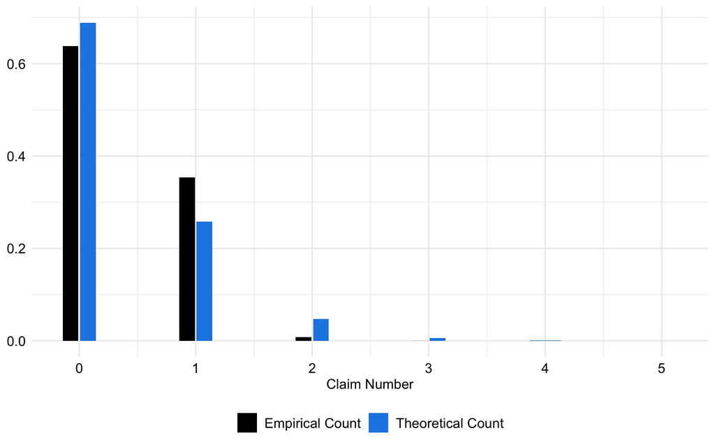

```r
ggplot(freq_combined, aes(x = Count, y = Frequency, fill = Source)) +
  geom_bar(stat = "identity", position = "dodge2", width = 0.3) +
  labs(x = "Claim Number", y = "Frequency", fill = "Legend") +
  theme(legend.position = "right") +
  scale_fill_manual(
    NULL,
    values = c("Empirical Count" = "black", "Theoretical Count" = "#1E88E5")
  ) +
  labs(fill = "Legend") +
  labs(x = "Claim Number", y = NULL) +
  theme(legend.position = "right")+
  global_theme()
```

```r
reg <- gam(
  ClaimNB ~ -1 + s(insured_age) + s(vehicle_age) + offset(log(exposure)),
  family = quasipoisson,
  data = CLAIMS
)

summary(reg)
```

```
Family: quasipoisson
Link function: log

Formula:
ClaimNB ~ -1 + s(insured_age) + s(vehicle_age) + offset(log(exposure))

Approximate significance of smooth terms:
                edf Ref.df   F p-value
s(insured_age) 4.80   5.78 105  <2e-16 ***
s(vehicle_age) 3.94   4.71 468  <2e-16 ***
---
Signif. codes:  0 '***' 0.001 '**' 0.01 '*' 0.05 '.' 0.1 ' ' 1

R-sq.(adj) =  -0.0915   Deviance explained =   -5%
GCV = 0.79694  Scale est. = 0.75161   n = 70791
```

This generalized additive model (GAM) predicts the number of claims based on `insured_age` and `vehicle_age` as predictors. The smooth terms in the model are statistically significant, indicating that both `insured_age` and `vehicle_age` have a meaningful effect on the number of claims.

# Graphs

**DriverAge vehicle_age 3D perspective influence**

**Code to create the following graph**

Figure 2: 3D impact perspective: DriverAge and vehicle_age

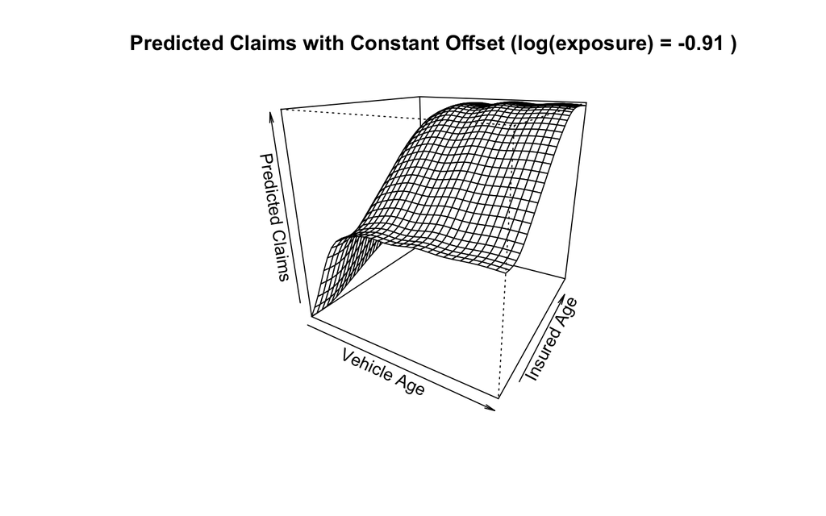

```r
constant_offset <- mean(log(CLAIMS$exposure))


pgam <- function(x1, x2){
  predict(
    reg,
    newdata = data.frame(
      vehicle_age = x1,
      insured_age = x2,
      exposure = exp(constant_offset)
    ),
    type = "response"
  )
}

M <- 31
cx1 <- seq(from = min(CLAIMS$vehicle_age), to = max(CLAIMS$vehicle_age), length = M)
cx2 <- seq(from = min(CLAIMS$insured_age), to = max(CLAIMS$insured_age), length = M)


Pgam <- outer(cx1, cx2, Vectorize(pgam))


persp(
  cx1, cx2, Pgam, theta = 30, phi = 20,
  xlab = "Vehicle Age", ylab = "Insured Age", zlab = "Predicted Claims",
  main = paste(
    "Predicted Claims with Constant Offset (log(exposure) =",
    round(constant_offset, 2), ")"
  )
)
```

**DriverAge**

**Code to create the following graph**

Figure 3: Estimated effects of DriverAge

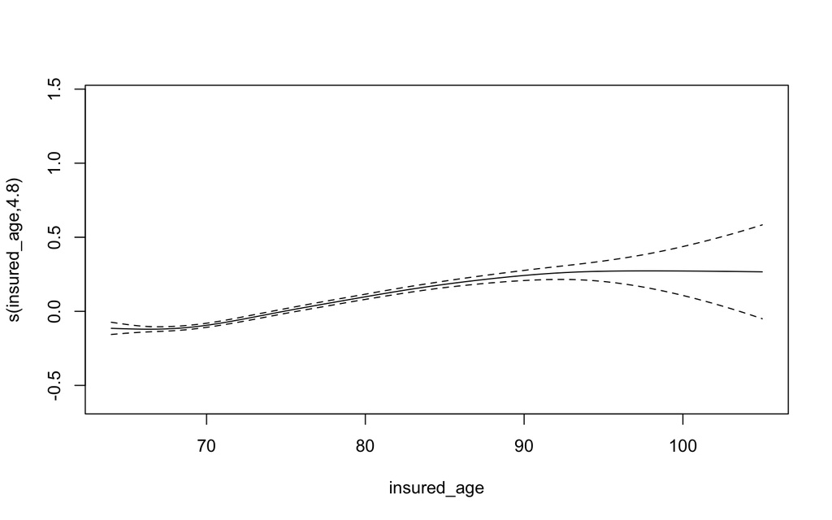

```r
plot(reg, select = 1)
```

The plot displays the smooth function of `insured_age` from the Generalized Additive Model (GAM). The solid line represents the estimated effect of `insured_age` on the log count of claims, with the dashed lines indicating 95% confidence intervals.

This plot suggests that insurers should consider the increasing risk with age, particularly for insured individuals over 80 years old, when assessing premiums and risk.

**vehicle_age**

**Code to create the following graph**

Figure 4: Estimated effects of vehicle age

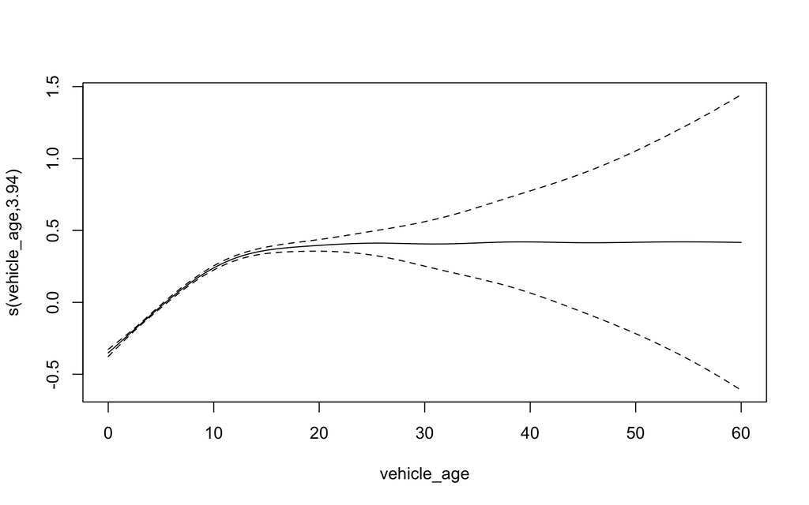

```r
plot(reg, select = 2)
```

# References

Agresti, Alan. 2013. *Categorical Data Analysis, 3rd Edition*.

Charpentier, Arthur. 2014. *Computational Actuarial Science with R*. The R Series. Chapman; Hall/CRC. https://www.routledge.com/Computational-Actuarial-Science-with-R/Charpentier/p/book/9781138033788.

# See also

For more similar claim frequency datasets with a Poisson-like distribution, see [`freMTPL`](https://dutangc.github.io/CASdatasets/reference/freMTPL.html) (import with `data("freMTPLfreq")`): French automobile dataset, [`norauto`](https://dutangc.github.io/CASdatasets/reference/norauto.html): Norwegian automobile dataset (import with `data("norauto")`), [`ausprivauto0405`](https://dutangc.github.io/CASdatasets/reference/ausprivauto.html) (import with `data("ausprivauto0405")`): Australian automobile dataset, or [`pg17trainpol`](https://dutangc.github.io/CASdatasets/reference/pricingame.html) (import with `data("pg17trainpol")`).